# Principal Component Analysis

Dataset water.sand.all.LUSI.red.scaled

This dataset contains 151 individuals and 8 variables, 1 qualitative variable is considered as illustrative.

### 1. Study of the outliers

The analysis of the graphs leads to detect outliers that strongly influence the results. First we will describe these outliers and then we will suppress them from the analysis. Looking at the graph, we can note that 3 particular individuals strongly contribute to the construction of the plane. The cumulative contribution of these individuals to the construction of the plane equals **42.4%**.

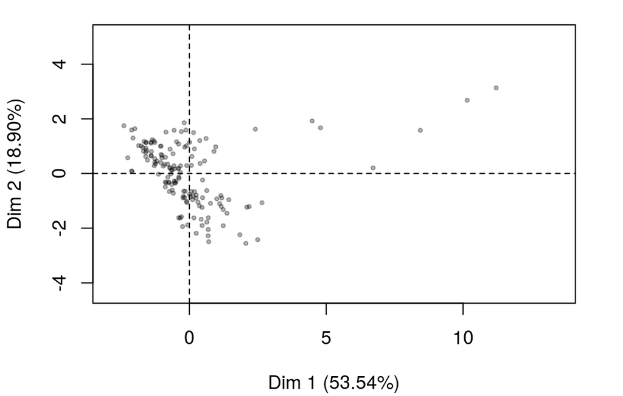

**Figure 1.1 - Individuals factor map (PCA) before correction.** *Highlighting of 3 outliers.*

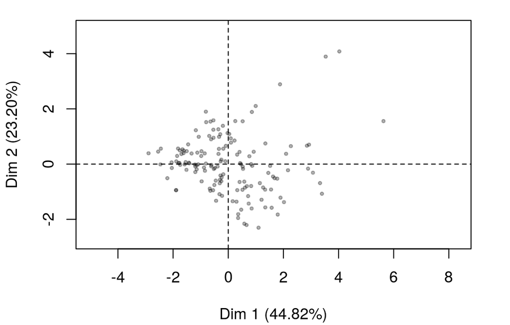

**Figure 1.2 - Individuals factor map (PCA) after correction.** *Highlighting of 3 outliers.*

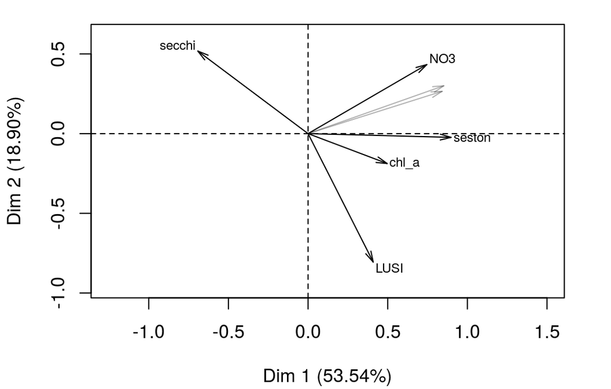

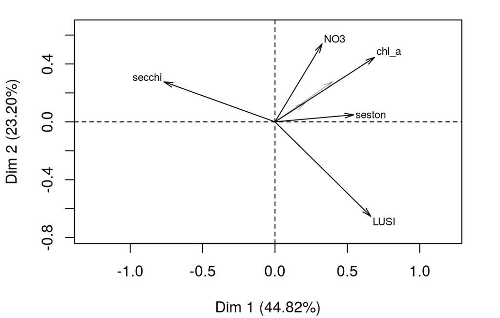

**Figure 1.3 - Variables factor map (PCA) after correction**

**The individual 8** :

- takes very high values for the variable(s) : *PO4*, *NO3*, *NH4* and *seston* (variables are sorted from the strongest).
- takes very low values for the variable(s) : *secchi*.

**The individual 33** :

- takes very high values for the variable(s) : *PO4*, *seston*, *NH4* and *NO3* (variables are sorted from the strongest).
- takes very low values for the variable(s) : *secchi*.

**The individual 58** :

- takes very high values for the variable(s) : *PO4*, *seston*, *NH4* and *NO3* (variables are sorted from the strongest).
- takes very low values for the variable(s) : *secchi*.

These outliers are suppressed from the analysis and a second one is performed on the rest of the individuals.

### 2. Inertia distribution

The inertia of the first dimensions shows if there are strong relationships between variables and suggests the number of dimensions that should be studied.

The first two dimensions of PCA express **68.02%** of the total dataset inertia ; that means that 68.02% of the individuals (or variables) cloud total variability is explained by the plane. This percentage is relatively high and thus the first plane well represents the data variability. This value is strongly greater than the reference value that equals **39.04%**, the variability explained by this plane is thus highly significant (the reference value is the 0.95-quantile of the inertia percentages distribution obtained by simulating 846 data tables of equivalent size on the basis of a normal distribution).

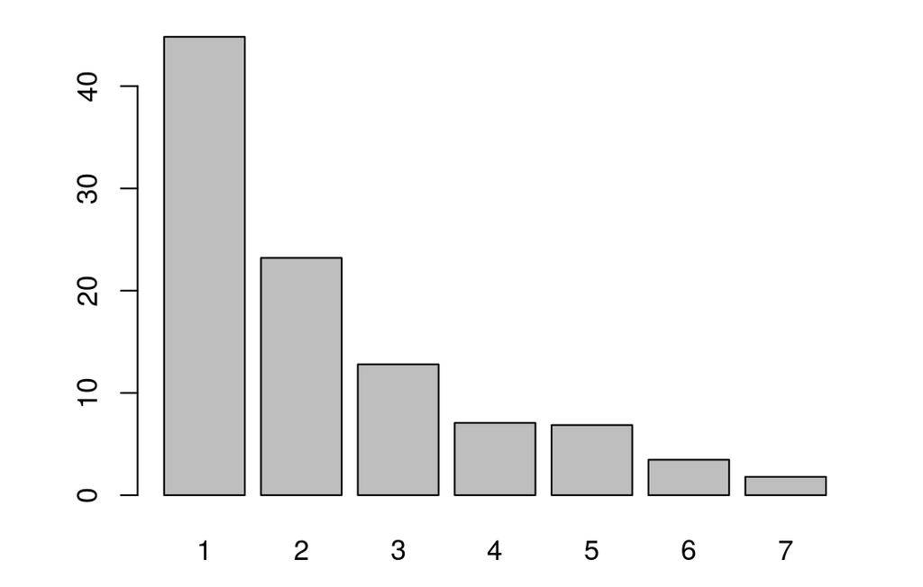

**Figure 2 - Decomposition of the total inertia on the components of the PCA**

An estimation of the right number of axis to interpret suggests to restrict the analysis to the description of the first 2 axis. These axis present an amount of inertia greater than those obtained by the 0.95-quantile of random distributions (68.02% against 39.04%). This observation suggests that only these axis are carrying a real information. As a consequence, the description will stand to these axis.

### 3. Description of the plane 1:2

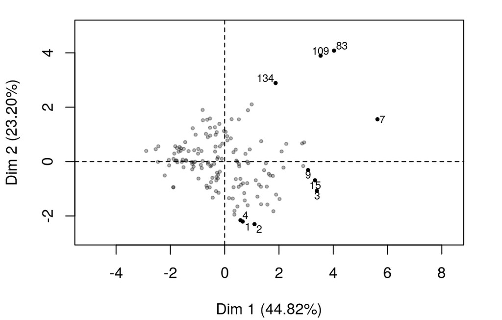

**Figure 3.1 - Individuals factor map (PCA)** *The labeled individuals are those with the higher contribution to the plane construction.*

The Wilks test p-value indicates which variable factors are the best separated on the plane (i.e. which one explain the best the distance between individuals).

```
##      station
## 3.938521e-59
```

There only is one possible qualitative variable to illustrate the distance between individuals : *station*.

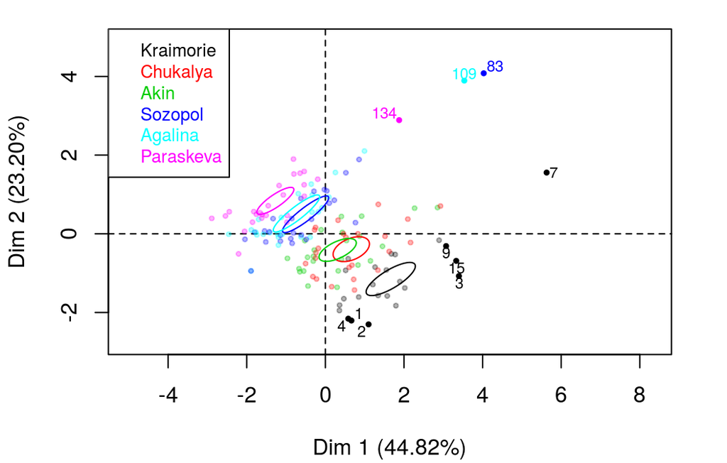

**Figure 3.2 - Individuals factor map (PCA)** *The labeled individuals are those with the higher contribution to the plane construction.* *The individuals are coloured after their category for the variable* station.

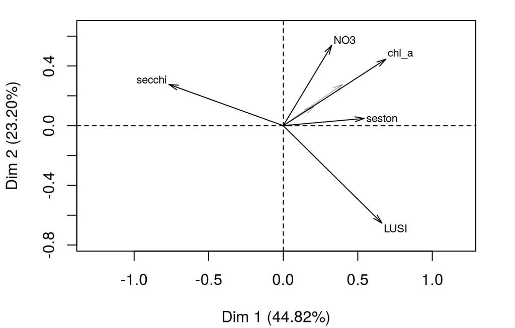

**Figure 3.3 - Variables factor map (PCA)** *The labeled variables are those the best shown on the plane.*

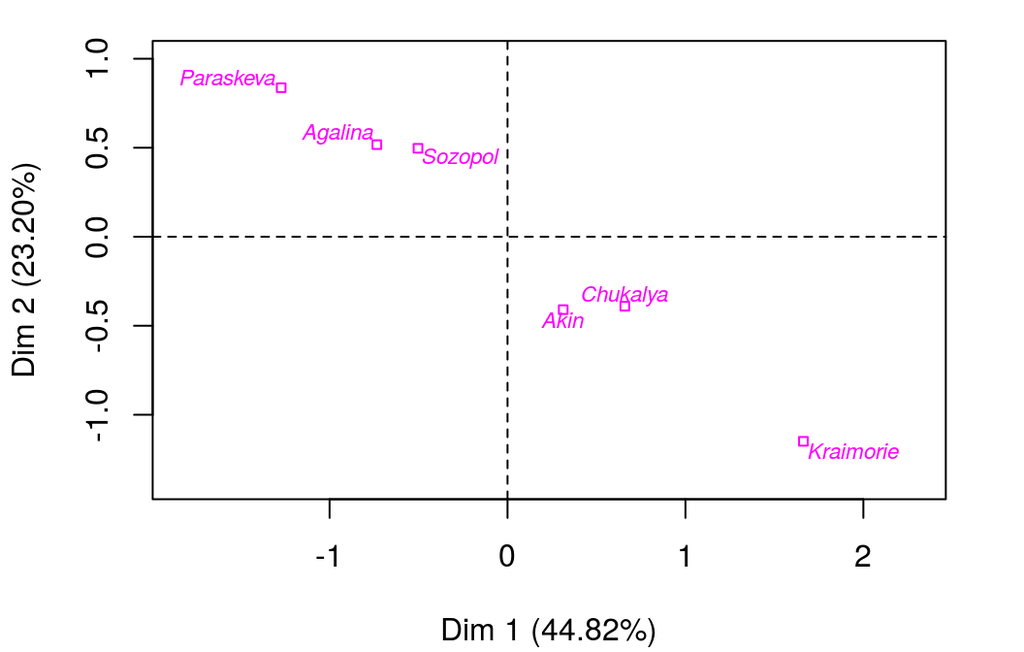

**Figure 3.4 - Qualitative factor map (PCA)** *The labeled factors are those the best shown on the plane.*

The group in which the individuals *1*, *4* and *2* stand (characterized by a positive coordinate on the axis) is sharing :

- high values for the variable *LUSI*.
- low values for the variables *secchi* and *NO3* (variables are sorted from the weakest).

The group in which the individuals *109*, *83*, *15*, *134*, *9*, *3* and *7* stand (characterized by a positive coordinate on the axis) is sharing :

- high values for the variables *chl_a*, *seston*, *NO3*, *NH4* and *PO4* (variables are sorted from the strongest).
- low values for the variable *secchi*.

The group 3 (characterized by a negative coordinate on the axis) is sharing :

- high values for the variable *secchi*.
- low values for the variables *LUSI*, *seston*, *chl_a*, *NH4*, *PO4* and *NO3* (variables are sorted from the weakest).

- high values for the variable *secchi*.
- low values for the variables *LUSI*, *seston*, *chl_a*, *NH4*, *PO4* and *NO3* (variables are sorted from the weakest).

The group in which the individuals *1*, *4* and *2* stand (characterized by a negative coordinate on the axis) is sharing :

- high values for the variable *LUSI*.
- low values for the variables *secchi* and *NO3* (variables are sorted from the weakest).

### 4. Classification

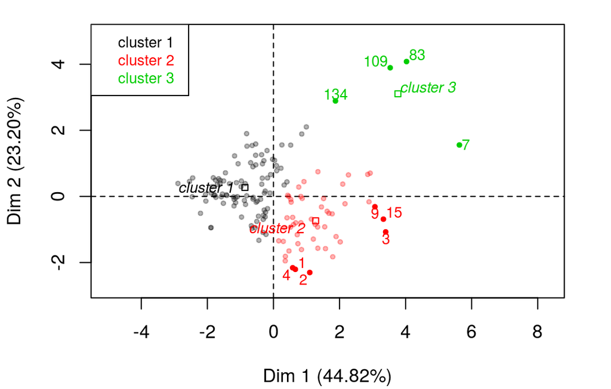

**Figure 4 - Ascending Hierarchical Classification of the individuals.** *The classification made on individuals reveals 3 clusters.*

The **cluster 1** is made of individuals sharing :

- high values for the variable *secchi*.
- low values for the variables *LUSI*, *seston*, *chl_a*, *PO4* and *NH4* (variables are sorted from the weakest).

The **cluster 2** is made of individuals such as *1*, *2*, *3*, *4*, *9* and *15*. This group is characterized by :

- high values for the variables *LUSI*, *seston* and *chl_a* (variables are sorted from the strongest).
- low values for the variable *secchi*.

The **cluster 3** is made of individuals such as *7*, *83*, *109* and *134*. This group is characterized by :

- high values for the variables *PO4*, *NO3*, *NH4*, *seston* and *chl_a* (variables are sorted from the strongest).
- low values for the variable *secchi*.

## Annexes

```r
dimdesc(res, axes = 1:2)
```

[output not shown]

**Figure 5 - List of variables characterizing the dimensions of the analysis.**

```r
res.hcpc$desc.var
```

```
Link between the cluster variable and the categorical variables (chi-square test)
=================================================================================
             p.value df
station 5.059693e-15 10

Description of each cluster by the categories
=============================================
$`1`
                   Cla/Mod   Mod/Cla   Global      p.value    v.test
station=Paraskeva 96.00000 25.806452 16.89189 4.859686e-05  4.062275
station=Agalina   96.00000 25.806452 16.89189 4.859686e-05  4.062275
station=Sozopol   92.30769 25.806452 17.56757 3.060428e-04  3.610131
station=Chukalya  37.50000  9.677419 16.21622 6.963898e-03 -2.698566
station=Kraimorie  0.00000  0.000000 16.21622 9.097224e-13 -7.143518

$`2`
                    Cla/Mod   Mod/Cla   Global      p.value    v.test
station=Kraimorie 95.833333 45.098039 16.21622 7.145958e-12  6.854706
station=Chukalya  62.500000 29.411765 16.21622 2.585321e-03  3.013172
station=Sozopol    3.846154  1.960784 17.56757 8.920455e-05 -3.918222
station=Paraskeva  0.000000  0.000000 16.89189 7.464054e-06 -4.480007
station=Agalina    0.000000  0.000000 16.89189 7.464054e-06 -4.480007

$`3`
NULL


Link between the cluster variable and the quantitative variables
================================================================
            Eta2      P-value
PO4    0.6471288 1.592840e-33
secchi 0.6011718 1.140175e-29
LUSI   0.5610674 1.185331e-26
NO3    0.4466394 2.333972e-19
seston 0.3920865 2.130739e-16
NH4    0.2696516 1.276237e-10
chl_a  0.2210260 1.365884e-08

Description of each cluster by quantitative variables
=====================================================
```

[output cut: 28 more lines]

```
$`3`
          v.test Mean in category Overall mean sd in category Overall sd
PO4     9.629516         1.796765  -0.12947098      0.8059115  0.4042150
NO3     8.064779         3.186308  -0.08244770      1.0742641  0.8190256
NH4     6.169040         2.153114  -0.09578572      1.5394577  0.7366479
seston  4.555650         1.450671  -0.09866665      1.1126786  0.6872315
chl_a   3.679420         1.808744  -0.01326486      0.7906072  1.0006418
secchi -3.302255        -1.456850   0.04608350      0.3425119  0.9196795
            p.value
PO4    6.001167e-22
NO3    7.336835e-16
NH4    6.870592e-10
seston 5.222392e-06
chl_a  2.337654e-04
secchi 9.591079e-04
```

**Figure 6 - List of variables characterizing the clusters of the classification.**